# Practicum SPSS 3 in R

In deze notebook wordt besproken hoe je de opdrachten uit “Practicum SPSS 3” in R kunt uitvoeren.

#### 1 - Lees de data in.

```r
library(tidyverse)
url <- "https://raw.githubusercontent.com/witusj/b-cluster/master/notes/data/data_woonwensen_ruw.csv"
myDF <- read.csv(url)
rbind(head(myDF, 5), tail(myDF, 5))
```

|  | X | WoSitnu | WoOppnu | WoLastnu | WoGemstu | Reistijd | Tevreden | Toelicht | Verhuisplan | VMsituatie | VMprijs | VMcampus | VMcentrum | VMhuisgenot | VMverplicht | VMander | WoOppwens | WoLastwens | Omgeveilig | Omgegroen | Omgebalkon | Omgeparking | OmgeOV | OmgeCentr | OmgeHAN | Woonbeeld1 | Woonbeeld2 | Woonbeeld3 | Woonbeeld4 | … |
| --- | --- | --- | --- | --- | --- | --- | --- | --- | --- | --- | --- | --- | --- | --- | --- | --- | --- | --- | --- | --- | --- | --- | --- | --- | --- | --- | --- | --- | --- | --- |
| 1 | 1 | Bij ouders | 14 | NA | nee | 41-60 min. | 7 | het is goedkoop en makkelijk wonen bij je ouders maar het is wel elke dag een eind naar school rijden. | weet ik (nog) niet | NA | NA | NA | NA | NA | NA | NA | 15 | 500 | belangrijk | onbelangrijk | neutraal | onbelangrijk | belangrijk | neutraal | neutraal | past wel | past niet | past enigszins | past wel | … |
| 2 | 2 | Bij ouders | NA | NA | nee | 21-40 min. | 9 | Ik heb het naar mijn zin thuis en kan mijn hobby ook beoefenen thuis. | nee, voorlopig niet van pan | NA | NA | NA | NA | NA | NA | NA | 50 | NA | zeer belangrijk | zeer belangrijk | zeer belangrijk | belangrijk | onbelangrijk | onbelangrijk | onbelangrijk | past helemaal niet | past niet | past helemaal niet | past enigszins | … |
| 3 | 3 | Bij ouders | NA | NA | nee | 61-90 min. | 7 | vind het fijn om thuis te wonen, maar heb soms wat meer rust voor mezelf nodig | weet ik (nog) niet | NA | NA | NA | NA | NA | NA | NA | 20 | 400 | belangrijk | neutraal | neutraal | neutraal | belangrijk | belangrijk | belangrijk | past wel | past enigszins | past wel | past enigszins | … |
| 4 | 4 | Bij ouders | NA | NA | nee | 61-90 min. | 8 |  | weet ik (nog) niet | NA | NA | NA | NA | NA | NA | NA | NA | 300 | belangrijk | belangrijk | belangrijk | onbelangrijk | neutraal | belangrijk | neutraal | past wel | past wel | past enigszins | past niet | … |
| 5 | 5 | Bij ouders | NA | NA | ja | 10-20 min. | 9 |  | ja, over meer dan 1 jaar | wel | wel | wel | wel | wel | wel | wel | 30 | 400 | belangrijk | belangrijk | neutraal | neutraal | neutraal | belangrijk | belangrijk | past niet | past wel | past wel | past wel | … |
| 265 | 265 | zelfstandige huurwoning | 27 | 532 | ja | 10-20 min. | 9 |  | nee, voorlopig niet van pan | NA | NA | NA | NA | NA | NA | NA | 25 | 550 | belangrijk | neutraal | neutraal | neutraal | zeer belangrijk | belangrijk | neutraal | past niet | past niet | past wel | past niet | … |
| 266 | 266 | zelfstandige huurwoning | 35 | 700 | nee | 61-90 min. | 5 |  | ja, binnen half jaar | 0 | 0 | 0 | 0 | 0 | 0 | wel | 15 | 650 | neutraal | belangrijk | neutraal | neutraal | zeer belangrijk | zeer belangrijk | neutraal | past niet | past enigszins | past niet | past wel | … |
| 267 | 267 | zelfstandige huurwoning | 50 | 450 | ja | minder dan 10 min. | 8 | Moderne woning, grote woonkamer, grote slaapkamers, keuken, bijkeuken en badkamer prima, huur wel net te hoog | weet ik (nog) niet | NA | NA | NA | NA | NA | NA | NA | 60 | 480 | belangrijk | neutraal | zeer belangrijk | onbelangrijk | belangrijk | belangrijk | neutraal | past volledig | past niet | past volledig | past enigszins | … |
| 268 | 268 | zelfstandige huurwoning | 60 | 450 | ja | 10-20 min. | 8 | Het is op loopafstand van station en stad en een prima appartement. | nee, voorlopig niet van pan | NA | NA | NA | NA | NA | NA | NA | 18 | 300 | neutraal | neutraal | neutraal | zeer belangrijk | zeer belangrijk | belangrijk | neutraal | past enigszins | past wel | past enigszins | past wel | … |
| 269 | 269 | anders | 40 | 850 | nee | 61-90 min. | 8 | Mocht dichterbij | ja, over een half jaar tot een jaar | 0 | 0 | 0 | 0 | 0 | 0 | wel | 16 | 450 | belangrijk | onbelangrijk | neutraal | neutraal | belangrijk | belangrijk | onbelangrijk | past helemaal niet | past helemaal niet | past volledig | past helemaal niet | … |

#### 2 - Beoordeel de kwaliteit van de data.

```r
str(myDF)
```

```
'data.frame':   269 obs. of  36 variables:
 $ X          : int  1 2 3 4 5 6 7 8 9 10 ...
 $ WoSitnu    : Factor w/ 6 levels "anders","Bij ouders",..: 2 2 2 2 2 2 2 2 2 2 ...
 $ WoOppnu    : int  14 NA NA NA NA NA NA NA 4 5 ...
 $ WoLastnu   : int  NA NA NA NA NA NA NA 150 NA 500 ...
 $ WoGemstu   : Factor w/ 2 levels "ja","nee": 2 2 2 2 1 2 2 2 1 2 ...
 $ Reistijd   : Factor w/ 6 levels "10-20 min.","21-40 min.",..: 3 2 4 4 1 4 5 2 2 2 ...
 $ Tevreden   : int  7 9 7 8 9 10 10 8 8 8 ...
 $ Toelicht   : Factor w/ 118 levels "                                                                                                               "| __truncated__,..: 31 50 109 1 1 1 1 105 107 1 ...
 $ Verhuisplan: Factor w/ 6 levels "ja, binnen half jaar",..: 6 5 6 6 3 6 3 3 5 5 ...
 $ VMsituatie : Factor w/ 2 levels "0","wel": NA NA NA NA 2 NA 2 2 NA NA ...
 $ VMprijs    : Factor w/ 2 levels "0","wel": NA NA NA NA 2 NA 1 2 NA NA ...
 $ VMcampus   : Factor w/ 2 levels "0","wel": NA NA NA NA 2 NA 1 1 NA NA ...
 $ VMcentrum  : Factor w/ 2 levels "0","wel": NA NA NA NA 2 NA 1 2 NA NA ...
 $ VMhuisgenot: Factor w/ 2 levels "0","wel": NA NA NA NA 2 NA 1 2 NA NA ...
```

[output cut: 22 more lines]

```r
summary(myDF)
```

```
       X                                                WoSitnu       WoOppnu
 Min.   :  1   anders                                       :  4   Min.   : 4.00
 1st Qu.: 68   Bij ouders                                   :202   1st Qu.:12.00
 Median :135   Eenkamerwoning met eigen voorzieningen       :  3   Median :16.00
 Mean   :135   Op kamers (gedeeld gebruik san. en/of keuken): 48   Mean   :20.42
 3rd Qu.:202   zelfstandige huurwoning                      : 11   3rd Qu.:23.00
 Max.   :269   zelfstandige koopwoning                      :  1   Max.   :80.00
                                                                   NA's   :16
    WoLastnu     WoGemstu                Reistijd     Tevreden
 Min.   : 30.0   ja : 80   10-20 min.        :36   Min.   : 3.000
 1st Qu.:300.0   nee:189   21-40 min.        :56   1st Qu.: 7.000
 Median :350.0             41-60 min.        :55   Median : 8.000
 Mean   :384.8             61-90 min.        :57   Mean   : 8.048
 3rd Qu.:438.8             langer dan 90 min.:26   3rd Qu.: 9.000
 Max.   :900.0             minder dan 10 min.:39   Max.   :10.000
 NA's   :191
                                                                                                                                                                                                                                                       Toelicht
                                                                                                                                                                                                                                                           :151
 nee                                                                                                                                                                                                                                                       :  2
 -                                                                                                                                                                                                                                                         :  1
 Alles is redelijk dichtbij.                                                                                                                                                                                                                               :  1
 Alles wordt geregeld                                                                                                                                                                                                                                      :  1
 Beetje klein maar heel dicht bij het station. Niet hele leuke huisgenoten.                                                                                                                                                                                :  1
 (Other)                                                                                                                                                                                                                                                   :112
                               Verhuisplan  VMsituatie VMprijs    VMcampus   VMcentrum
 ja, binnen half jaar                : 29   0   : 36   0   : 85   0   : 47   0   : 52
 ja, over een  half jaar tot een jaar: 43   wel : 75   wel : 26   wel : 64   wel : 59
 ja, over meer dan 1 jaar            : 32   NA's:158   NA's:158   NA's:158   NA's:158
 ja, zeer korte termijn              :  7
 nee, voorlopig niet van pan         :124
 weet ik  (nog)  niet                : 34

 VMhuisgenot VMverplicht VMander      WoOppwens       WoLastwens               Omgeveilig
 0   : 64    0   :105    0   : 95   Min.   : 5.00   Min.   :  20.0   belangrijk     :140
 wel : 47    wel :  6    wel : 16   1st Qu.:15.00   1st Qu.: 350.0   neutraal       : 57
 NA's:158    NA's:158    NA's:158   Median :18.00   Median : 400.0   onbelangrijk   :  5
                                    Mean   :20.36   Mean   : 406.9   zeer belangrijk: 67
                                    3rd Qu.:20.00   3rd Qu.: 450.0
                                    Max.   :80.00   Max.   :1000.0
                                    NA's   :23      NA's   :21
```

[output cut: 37 more lines]

```
 3rd Qu.: 850.0
 Max.   :2500.0
 NA's   :1
                                                                                                                                                                                                                                                     Opmerkingen
                                                                                                                                                                                                                                                           :124
 Nee                                                                                                                                                                                                                                                       : 39
 nee                                                                                                                                                                                                                                                       : 34
 -                                                                                                                                                                                                                                                         :  7
 Nope                                                                                                                                                                                                                                                      :  3
 /                                                                                                                                                                                                                                                         :  1
 (Other)                                                                                                                                                                                                                                                   : 61
         filter_.
 Not Selected:  1
 Selected    :247
 NA's        : 21
```

#### 3 - Bewerk de data.

De variabele `Verhuisplan` heeft het formaat `long`; er is één kolom en iedere cel kan één waarde uit een set van 6 aannemen.

```r
with(myDF, levels(Verhuisplan)) %>% data.frame()
```

| . |
| --- |
| ja, binnen half jaar |
| ja, over een half jaar tot een jaar |
| ja, over meer dan 1 jaar |
| ja, zeer korte termijn |
| nee, voorlopig niet van pan |
| weet ik (nog) niet |

We hebben ook een set van variabelen (Verhuismotief - begint met `VM`) die één waarde uit een set van twee aan kan nemen (wel/niet). Dit type data noemen we `boolean`. We gaan de kolommen combineren in twee kolommen: key en de value. Daarna kunnen we tabellen met verhoudingen bouwen. In de eerste kolom wordt het aantal antwoorden geteld (`count`), in de tweede worden de aantallen gerelateerd aan het totaal aantal gegeven antwoorden en in de derde kolom worden de aantallen gerelateerd aan het aantal studenten dat antwoord heeft gegeven.

```r
vmDF <- select(myDF, c(X, contains("VM")))
vmDF.long <- gather(vmDF, key, value, -X)
vmDF.long[sample(1:dim(vmDF.long)[1], 10),] %>% arrange(X)
```

| X | key | value |
| --- | --- | --- |
| 5 | VMprijs | wel |
| 51 | VMcentrum | NA |
| 119 | VMhuisgenot | NA |
| 149 | VMcampus | wel |
| 166 | VMsituatie | NA |
| 176 | VMcampus | NA |
| 207 | VMhuisgenot | wel |
| 214 | VMsituatie | NA |
| 248 | VMander | 0 |
| 253 | VMverplicht | 0 |

```r
grpVM <- vmDF.long %>%
  filter(value == "wel") %>%
  group_by(X) %>%
  summarize(count = n())
tabVM <- vmDF.long %>%
  filter(value == "wel") %>%
  group_by(key) %>%
  summarize(count = n()) %>%
  mutate(responses = count / sum(count), cases = count / dim(grpVM)[1])
totVM <- c("Totaal", sapply(list(tabVM$count, tabVM$responses, tabVM$cases), sum))
tabVM <- rbind(tabVM, totVM)
tabVM
```

| key | count | responses | cases |
| --- | --- | --- | --- |
| VMander | 16 | 0.0546075085324232 | 0.144144144144144 |
| VMcampus | 64 | 0.218430034129693 | 0.576576576576577 |
| VMcentrum | 59 | 0.201365187713311 | 0.531531531531532 |
| VMhuisgenot | 47 | 0.160409556313993 | 0.423423423423423 |
| VMprijs | 26 | 0.0887372013651877 | 0.234234234234234 |
| VMsituatie | 75 | 0.255972696245734 | 0.675675675675676 |
| VMverplicht | 6 | 0.0204778156996587 | 0.0540540540540541 |
| Totaal | 293 | 1 | 2.63963963963964 |

We hebben een andere set van variabelen (Omgevingsaaspecten - begint met `Omge`) die één waarde uit een set van meerdere aan kan nemen (van `zeer onbelangrijk` tot `zeer belangrijk`) - `multiple response`. Ook deze kolommen combineren we in twee kolommen: key en de value. Daarna kunnen we een tabel bouwen waaruit we kunnen aflezen in welke mate aspecten belangrijk zijn voor een woningkeuze. In een grafiek `bar chart` worden de verhoudingen beter zichtbaar.

```r
library(knitr)
omgDF <- select(myDF, c(X, contains("Omge")))
omgDF.long <- gather(omgDF, key, value, -X)
omgDF.long$value <- factor(omgDF.long$value, levels = c("zeer onbelangrijk", "onbelangrijk", "neutraal", "belangrijk", "zeer belangrijk"))
omgTab <- with(omgDF.long, table(key, value))
kable(omgTab)
```

|  | zeer onbelangrijk | onbelangrijk | neutraal | belangrijk | zeer belangrijk |
| --- | --- | --- | --- | --- | --- |
| Omgebalkon | 3 | 30 | 99 | 96 | 41 |
| OmgeCentr | 1 | 19 | 91 | 110 | 48 |
| Omgegroen | 7 | 46 | 154 | 52 | 10 |
| OmgeHAN | 10 | 56 | 125 | 66 | 12 |
| OmgeOV | 1 | 10 | 26 | 131 | 101 |
| Omgeparking | 13 | 76 | 87 | 59 | 34 |
| Omgeveilig | 0 | 5 | 57 | 140 | 67 |

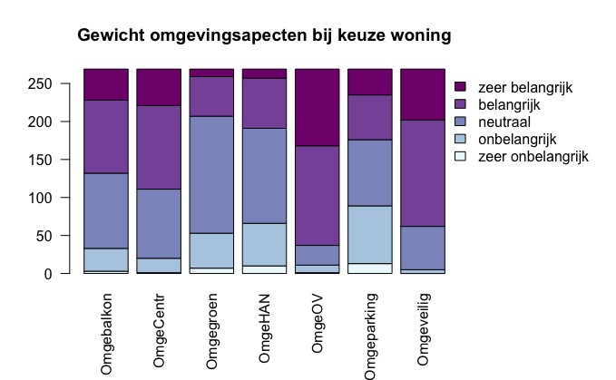

```r
library(RColorBrewer)
cols <- brewer.pal(dim(omgTab)[2], "BuPu")
par(mar=c(6,4,4,9))
barplot(t(omgTab), main="Gewicht omgevingsapecten bij keuze woning",
        col=cols,
        legend = rownames(t(omgTab)),
        las=2,
        args.legend = list(x = "topright", bty = "n", inset=c(-0.35, 0)))
```

Is er een verschil in het belang dat gehecht wordt aan veiligheid in de woonomgeving tussen mannen en vrouwen?

```r
myDF <- filter(myDF, Geslacht != "3")
myDF$Geslacht <- factor(myDF$Geslacht, levels = c("man", "vrouw"))
myDF$Omgeveilig <- factor(myDF$Omgeveilig, levels = c("zeer onbelangrijk", "onbelangrijk", "neutraal", "belangrijk", "zeer belangrijk"))
vlgTab <- with(myDF, table(Geslacht, Omgeveilig))
kable(prop.table(vlgTab,1))
```

|  | zeer onbelangrijk | onbelangrijk | neutraal | belangrijk | zeer belangrijk |
| --- | --- | --- | --- | --- | --- |
| man | 0 | 0.0378788 | 0.2878788 | 0.5000000 | 0.1742424 |
| vrouw | 0 | 0.0000000 | 0.1397059 | 0.5367647 | 0.3235294 |

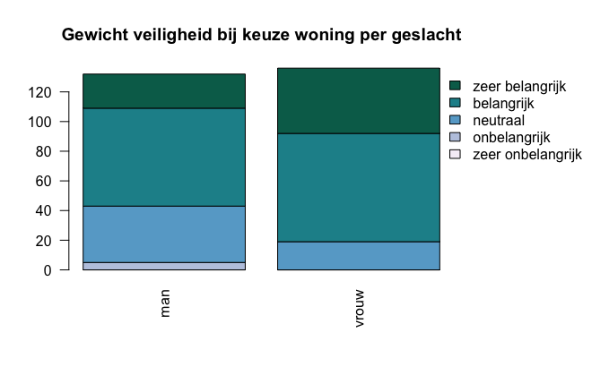

```r
cols <- brewer.pal(dim(omgTab)[2], "PuBuGn")
par(mar=c(6,4,4,9))
barplot(t(vlgTab), main="Gewicht veiligheid bij keuze woning per geslacht",
        col=cols,
        legend = rownames(t(vlgTab)),
        las=2,
        args.legend = list(x = "topright", bty = "n", inset=c(-0.35, 0)))
```

Is er een verschil in inkomen tussen mannen en vrouwen?

```r
myDF %>%
  group_by(Geslacht) %>%
  summarize(Gem.Ink = mean(Inkomen, na.rm = TRUE), sd = sd(Inkomen, na.rm = TRUE))
```

| Geslacht | Gem.Ink | sd |
| --- | --- | --- |
| man | 640.6591 | 409.3383 |
| vrouw | 593.1630 | 342.5275 |

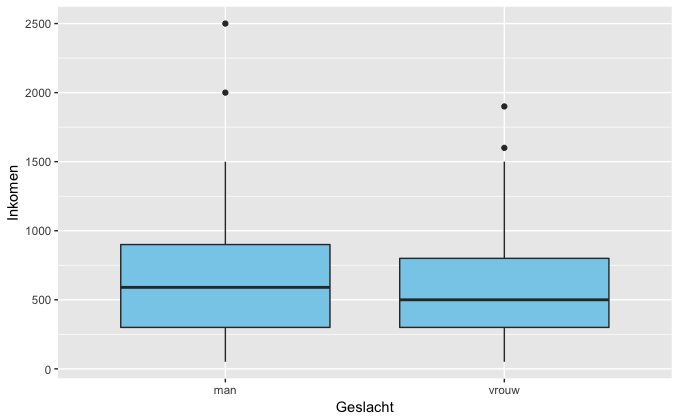

```r
ggplot(myDF, aes(x = Geslacht, y = Inkomen)) +
        geom_boxplot(fill = "Skyblue")
```

Is er een samenhang tussen oppervlakte en woonlast?

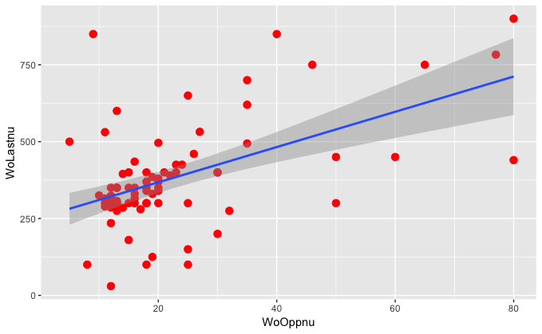

```r
ggplot(myDF, aes(x=WoOppnu, y=WoLastnu)) +
  geom_point(colour = "red", size = 3) +
  geom_smooth(method='lm')
```